# Chapter 4 Hypothesis testing and statistical inference

### Senario 1:

A company manufactures rivets that are used in the construction of aircraft. Because these rivets are critical structural components, one key quality characteristic is their shearing strength, measured in pounds (lb). To ensure safety and reliability, the company has established a specification stating that the mean shearing strength of all rivets produced must exceed 1000 lb.

To monitor whether the production process is meeting this requirement, the engineers periodically collect samples of rivets and test their shearing strength. In one quality-control check, a random sample of 64 rivets is selected from the production line. Laboratory testing shows that the sample mean shearing strength is 1012.70 lb, and the sample standard deviation is 45 lb.

The engineers want to determine whether the data from this sample provide sufficient statistical evidence to support the claim that the true mean shearing strength of all rivets produced by the company is greater than 1000 lb.

In other words, based on this sample, can we conclude that the production process meets the required specification? To answer this question, we need a statistical method that evaluates the strength of evidence in the sample data for or against a claim about a population parameter.

In this chapter, we will learn how to use statistical hypothesis testing to assess whether the observed sample data provide enough evidence to support the claim that the population mean shearing strength exceeds 1000 lb.

Note: The claim in this problem concerns the population mean (average) shearing strength of all rivets produced by the company.

A dataset: 1022.03, 991.42, 1030.55, 1002.71, 996.84, 1016.12, 1030.28, 993.51, 1025.02, 998.63, 987.59, 1006.31, 1028.67, 1026.34, 1018.22, 986.05, 1039.24, 1018.19, 1004.78, 1024.61, 1013.73, 1019.04, 992.81, 1005.57, 1011.62, 1012.94, 1001.82, 1018.31, 1014.36, 1011.88, 1020.11, 996.85, 1005.26, 1013.07, 1005.48, 996.29

### Senario 2:

A pharmaceutical company is conducting a small clinical study to evaluate whether a newly developed drug can reduce systolic blood pressure in patients diagnosed with mild hypertension. The study recruits 20 adult patients who have similar baseline health conditions and are not currently taking other blood pressure medications.

At the beginning of the study, each participant’s systolic blood pressure (in mmHg) is measured during a routine clinical visit. The participants are then instructed to take the new medication once daily for four weeks. At the end of the four-week treatment period, their systolic blood pressure is measured again under the same conditions. The goal is to determine whether the drug leads to a reduction in blood pressure on average.

The paired measurements for each patient are recorded below.

| Patient | Before Treatment | After Treatment |
| --- | --- | --- |
| 1 | 120 | 115 |
| 2 | 122 | 120 |
| 3 | 118 | 112 |
| 4 | 130 | 128 |
| 5 | 125 | 122 |
| 6 | 128 | 125 |
| 7 | 115 | 110 |
| 8 | 121 | 117 |
| 9 | 123 | 119 |
| 10 | 119 | 114 |
| 11 | 132 | 127 |
| 12 | 127 | 124 |
| 13 | 124 | 120 |
| 14 | 129 | 126 |
| 15 | 117 | 112 |
| 16 | 126 | 122 |
| 17 | 131 | 128 |
| 18 | 118 | 113 |
| 19 | 122 | 118 |
| 20 | 125 | 121 |

### Blood pressure data

before <- c(120,122,118,130,125,128,115,121,123,119, 132,127,124,129,117,126,131,118,122,125)

after <- c(115,120,112,128,122,125,110,117,119,114, 127,124,120,126,112,122,128,113,118,121)

Once sample data has been gathered through an observational study or experiment, statistical inference allows analysts to assess evidence in favor of some claim (statement) about the population from which the sample has been drawn. The methods of inference used to support or reject claims (statements) based on sample data are known as **hypothesis testing** (tests of significance). The goal of hypothesis testing is to assess the evidence provided by the sample in favor of some claim about the population parameter(s).

**Hypothesis testing** assesses the amount of evidence in the data to support a statement about a population (or populations).

- **Hypothesis:** a statement about a population (or populations).

Can we tell if a hypothesis is true or false without all data from the population for sure? Usually we cannot. We need to test it.

Steps for a hypothesis testing

1. Setup the null (H0) and the alternative hypothesis (H1) according to the purpose of the study
2. Find the right test , depending on the data, and the problem/purpose
3. Calculation ( test statistic, p-value)
4. State the level of significance, based on the p-value, make a decision ( reject H0, or Fail to reject H0)
5. Draw a conclusion based on the decision

Or make adjustment accordingly based on situations.

6. Verify the assumptions if we have not done it in step 2.

The null hypthosis (H0) is a statement of no effects, no differences, ...

The alternative hypthosis (H1) is a statement of effects, differences, ... ( >, <, or $\ne$)

Example for Step 1: setup the null and the alternative

If the purpose is to "to determine whether the mean shearing strength of all rivets by the company is greater than 1000 lb."

H0: the mean shearing strength of all rivets by the company is 1000 lb ($ \mu = 1000 $)

H1: the mean shearing strength of all rivets by the company is greater than 1000 lb. ($ \mu > 1000 $)

Example: A pharmaceutical company is conducting a small clinical study to evaluate whether a newly developed drug can reduce systolic blood pressure in patients diagnosed with mild hypertension. Please setup H0 and H1.

H0: a newly developed drug has no effects to reduce systolic blood pressure in patients diagnosed with mild hypertension. $H_0: \mu_{without} = \mu_{drug} $

H1: a newly developed drug can reduce systolic blood pressure in patients diagnosed with mild hypertension $H_1: \mu_{without} > \mu_{drug} $

Example:

To monitor whether the production process is meeting this requirement, the engineers periodically collect samples of rivets and test their shearing strength. In one quality-control check, a random sample of 64 rivets is selected from the production line. Laboratory testing shows that the sample mean shearing strength is 1012.70 lb, and the sample standard deviation is 45 lb. Run a hypothesis testing to determine whether the mean shearing strength of all rivets by the company is greater than 1000 lb.

4.1 One sample t test about a population mean $\mu$

To test if a population mean is > , or < or $\ne$ to a given number.

Requirements:  
1. The observations are independent.  
2. The observations are from a normal distribution approxiamtely, especailly when the sample size is not large.

Example: Use the diamond data. Conduct a test to see if the mean price of diamond in the market with color 'E' is more than 3000, at signifcant level of 0.01.

$\mu$: the mean price of diamond in the market (unknown)

$H_0$: the mean price of diamond in the market with color 'E' is 3000

$H_1$: the mean price of diamond in the market with color 'E' is more than 3000 or ( $\mu > 3000$ ), where $\mu$ is the mean price of diamond in the market with color 'E'

What test? One sample t test (verify the requirements) The QQ normal plot indicates that the data are from a normal distribution approximatly, then we can run one sample test test.

Test statistic = t = 1.0565, df = 15, p-value = 0.1537

Decision: the level of significance = 0.01. Since p-value = 0.1537 is greater than the level of signifcance, fail to reject $H_0$.

Conclusion: There is no sufficient evidence in the data to support H1 that the mean price of diamond in the market with color 'E' is more than 3000.

```r
loc = "diamond.csv"
 dat = read.csv(loc, header = 1)
 head(dat)
```

A data.frame: 6 × 5

|  | Weight <dbl> | Color <chr> | Clarity <chr> | Certificate <chr> | Price <int> |
| --- | --- | --- | --- | --- | --- |
| 1 | 0.30 | D | VS2 | GIA | 1302 |
| 2 | 0.30 | E | VS1 | GIA | 1510 |
| 3 | 0.30 | G | VVS1 | GIA | 1510 |
| 4 | 0.30 | G | VS1 | GIA | 1260 |
| 5 | 0.31 | D | VS1 | GIA | 1641 |
| 6 | 0.31 | E | VS1 | GIA | 1555 |

1. 1510

2. 1555

3. 1327

4. 1693

5. 1738

6. 2942

7. 3501

8. 3501

9. 3635

10. 3767

11. 4138

12. 5845

13. 3501

14. 3900

15. 6512

16. 5800

16

```
	One Sample t-test

data:  priceE
t = 1.0565, df = 15, p-value = 0.1537
alternative hypothesis: true mean is greater than 3000
95 percent confidence interval:
 2717.118      Inf
sample estimates:
mean of x
 3429.062
```

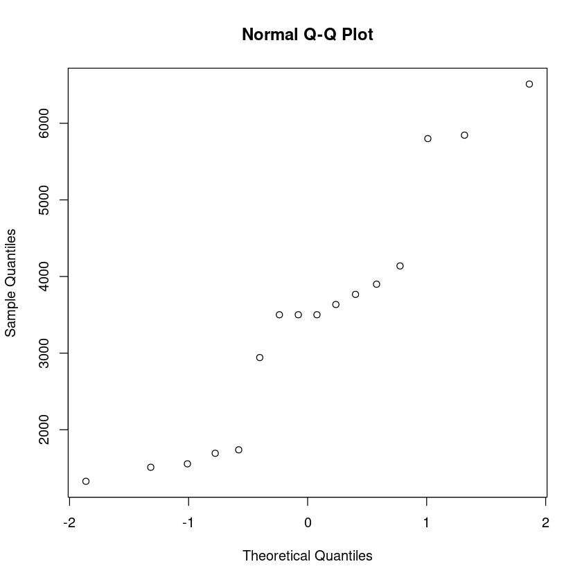

```r
#One sample t test
#Verify the requirements

priceE= dat$Price[dat$Color == 'E']

priceE

#To obtain the sample size
length(priceE)

#16 is not very large
#Check the normality
qqnorm(priceE)



#the data are from a normal distribution approximatly, then we can run one sample test test.
#t.test(x, y = NULL,      alternative = c("two.sided", "less", "greater"),        mu = 0, paired = FALSE, var.equal = FALSE, conf.level = 0.95, ...)

t.test(priceE, alternative = "greater",  mu= 3000 )
```

### Practical question:

Use the diamond data. Conduct a test to see if the mean weight of diamond in the market with color 'E' is **different than** 0.25, at signifcant level of 0.05.

....

Test statistic = t = 7.5, df = 15, p-value = 1.86x10E-06 = 0.00000186

Decision: the level of significance = 0.05. Since p-value = 0.00000186 is below the level of signifcance, reject $H_0$.

Conclusion: There is sufficient evidence in the data to support H1 that the mean weight of diamond in the market with color 'E' is **different than** 0.25.

1. 0.3

2. 0.31

3. 0.33

4. 0.34

5. 0.35

6. 0.46

7. 0.5

8. 0.5

9. 0.52

10. 0.54

11. 0.55

12. 0.62

13. 0.5

14. 0.56

15. 0.63

16. 0.7

16

```
	One Sample t-test

data:  WeightE
t = 7.5091, df = 15, p-value = 1.861e-06
alternative hypothesis: true mean is not equal to 0.25
95 percent confidence interval:
 0.4160579 0.5476921
sample estimates:
mean of x
 0.481875
```

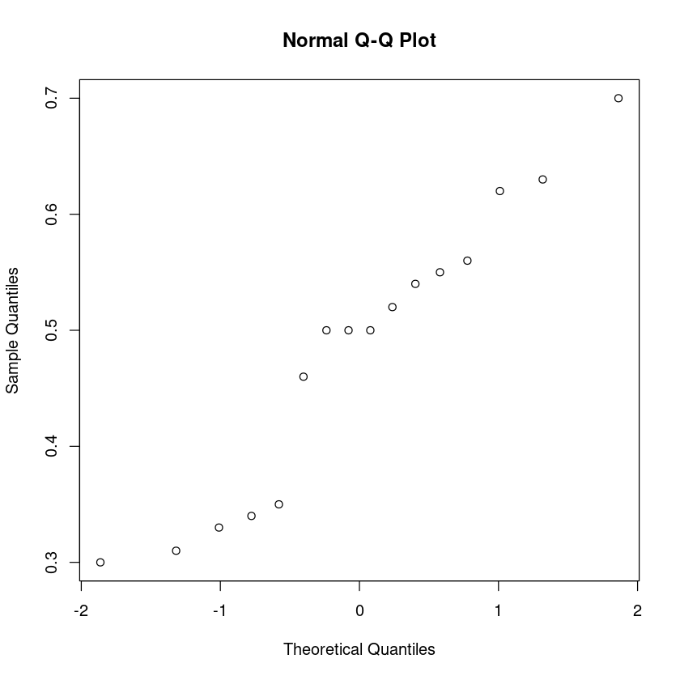

```r
WeightE= dat$Weight[dat$Color == 'E']

WeightE

#To obtain the sample size
length(WeightE)

#16 is not very large
#Check the normality
qqnorm(WeightE)

t.test(WeightE, alternative = "two.sided",  mu= 0.25 )
```

4.2 One sample proportion test about a population proportion $p$

Two tests based on large sample or not:

A large sample one proportion z test ( $x \ge 5$ and $n-x \ge 5$ )

Binomial exact test (when the sample size is not large enough : either $x$ or $n-x$ is less than 5)

Example: Use the diamond data. Conduct a test to see if the proportion of diamond in the market with color 'E' is less than 0.1, at signifcant level of 0.01.

$p$: the proportion of diamond in the market with color 'E' ( unknown)

$H_0$: the proportion of diamond in the market with color 'E' is 0.1.

$H_1$: the proportion of diamond in the market with color 'E' is less than 0.1

```
      $p < 0.1$
```

What test? Large sample test for a population proportion

Test statistic = X-squared = 6.0494, p-value = 0.993

Decision: the level of significance = 0.01 . Since p-value = 0.993 is above the level of signifcance, _fail to_______ reject $H_0$.

Conclusion: There is ___no_______ sufficient evidence in the data to support H1 that the proportion of diamond in the market with color 'E' is less than 0.1.

# prop.test(x, n, p = NULL,

# alternative = c("two.sided", "less", "greater"),

# conf.level = 0.95, correct = TRUE)

```r
table(dat$Color)

length(dat$Color)
#x = 16,    n-x = 90 - 16 = 74

#Both are above 5

prop.test(16,  90, p = 0.1, alternative = "less", correct = FALSE)

#If the sample size is not large enough ,  we will need binomial exact test
```

```
 D  E  F  G  H  I
 4 16 27 18 17  8
```

90

```
	1-sample proportions test without continuity correction

data:  16 out of 90, null probability 0.1
X-squared = 6.0494, df = 1, p-value = 0.993
alternative hypothesis: true p is less than 0.1
95 percent confidence interval:
 0.0000000 0.2531693
sample estimates:
        p
0.1777778
```

```r
?prop.test
```

### Two sample t tests to compare two population means ($\mu_1$, $\mu_2$)

a. Two independent samples

If the observations in two groups have nothing to do with each other, these two samples are independent.

b. Paired samples

If one observation in one group is paired (matched) with one particular observation in another group, then these two samples are dependent samples.

The information is given in the question about how the data are collected and how the study was designed.

Example: to compare two brand of tires in terms of the average MPG.

Option 1: randomly select 50 cars to be group 1 with brand A; and randomly select 72 cars to be group 2 using brand B Brand A: x1, x2, x3, ... x50 Brand B: y2, y1, ... y72

Do we see any connenction between x1 and y1 ? Not at all. In this case, these two samples are independent samples.

Option 2: randomly select 50 cars. First we use Brand A and record MPG; then use Brand B on these cars and record MPG. Car1 Car 2 .... Car 50 Brand A: x1 x2 ... x50 Brand B: y1 y2 ... y50

In this case, x1 and y1 are both MPG for car 1.There are paired or related. These two samples are dependent samples.

To compare two population means, if two samples are independent: 1. Welsh t test  
2. Pooled t test (when two population varaiances are the same, but we need to test it)

If two samples are dependent samples, we will need pair t test.

Example: a. Mosquito repellents. Researchers were interested in comparing the effectiveness of two mosquito repellents. Two groups of individuals participated in the study. The results were: Repellent A: 5, 12, 33, 17, 9, 3, 6, 12, 20, 14, 7, 12, 25, 6, 4, 5 Repellent B: 12, 19, 36, 15, 18, 7, 5, 12, 26, 27, 10, 11, 22, 13, 11, 5 At significance level of 0.01, is there enough evidence that Repellent A is more effective than Repellent B?  
Independent samples. Two independent sample t test.

b. Mosquito repellents. Researchers were interested in comparing the effectiveness of two mosquito repellents. Repellent A was applied on one arm and Repellent B was applied on the other. The results were: Repellent A: 5, 12, 33, 17, 9, 3, 6, 12, 20, 14, 7, 12, 25, 6, 4, 5 Repellent B: 12, 19, 36, 15, 18, 7, 5, 12, 26, 27, 10, 11, 22, 13, 11, 5 At significance level of 0.01, is there enough evidence that Repellent A is more effective than Repellent B?

```
Dependent samples.  Paired t test.
```

Example: Use the diamond data. Run a test to determine if the average price of diamond with color 'E' is higher than that of diamond with color "H" in the market, at significance level of 0.01.

In R: t.test to run a t test.

$H_0$: the average price of diamond with color 'E' is the same as that of diamond with color "H" in the market

```
          $\mu_E = \mu_H$
```

$H_1$: the average price of diamond with color 'E' is higher than that of diamond with color "H" in the market

```
         $\mu_E > \mu_H$
```

Independent samples: Welsh t test Requirements: normality of ***both samples*** when the sample sizes are not large enough.

Test statistic t = 0.17983, df = 30.045, p-value = 0.4292

The level of significance is 0.01. Based on the p-value, fail to reject H0 because p-value is greater than the level of significance.

There is no sufficient evidence in the data to support H1 that the average price of diamond with color 'E' is higher than that of diamond with color "H" in the market.

```r
loc = "diamond.csv"
 dat = read.csv(loc, header = 1)
 head(dat)
```

A data.frame: 6 × 5

|  | Weight <dbl> | Color <chr> | Clarity <chr> | Certificate <chr> | Price <int> |
| --- | --- | --- | --- | --- | --- |
| 1 | 0.30 | D | VS2 | GIA | 1302 |
| 2 | 0.30 | E | VS1 | GIA | 1510 |
| 3 | 0.30 | G | VVS1 | GIA | 1510 |
| 4 | 0.30 | G | VS1 | GIA | 1260 |
| 5 | 0.31 | D | VS1 | GIA | 1641 |
| 6 | 0.31 | E | VS1 | GIA | 1555 |

16

17

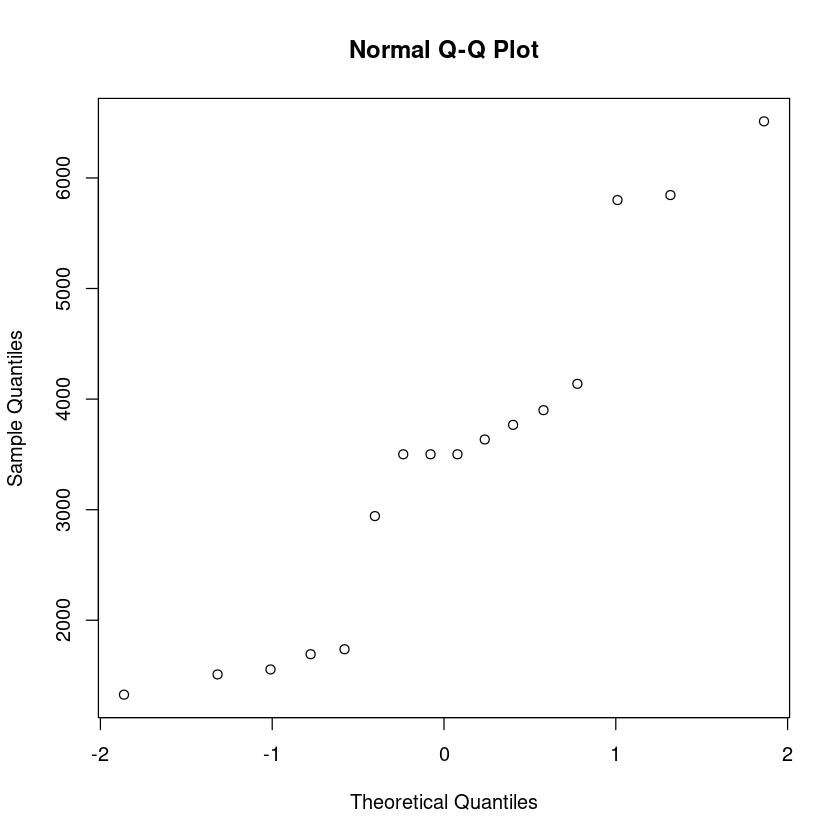

```
	Welch Two Sample t-test

data:  priceE and priceH
t = 0.17983, df = 30.045, p-value = 0.4292
alternative hypothesis: true difference in means is greater than 0
95 percent confidence interval:
 -980.766      Inf
sample estimates:
mean of x mean of y
 3429.062  3312.824
```

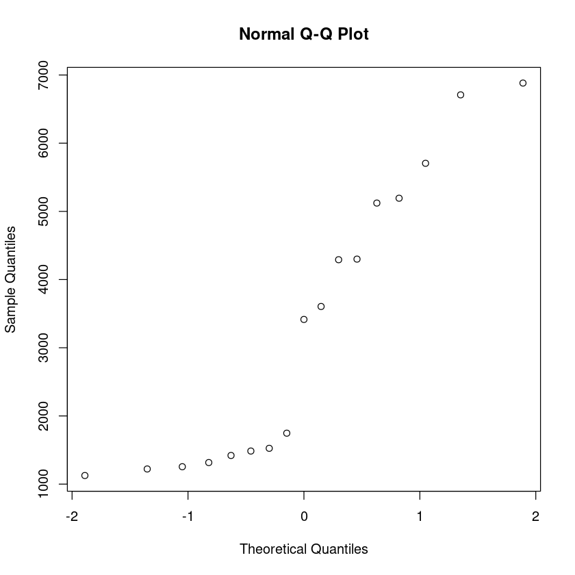

```r
priceE= dat$Price[ dat$Color=="E"]

priceH= dat$Price[ dat$Color=="H"]

length(priceE)

length(priceH)

#The sample sizes are not very large

qqnorm(priceE)
qqnorm(priceH)

#Both variables are from normal distributions approximately.

#Welsh t
t.test(priceE, priceH, alternative = "greater")
```

Example: A pharmaceutical company is conducting a small clinical study to evaluate whether a newly developed drug can reduce systolic blood pressure in patients diagnosed with mild hypertension. The study recruits 20 adult patients who have similar baseline health conditions and are not currently taking other blood pressure medications.

At the beginning of the study, each participant’s systolic blood pressure (in mmHg) is measured during a routine clinical visit. The participants are then instructed to take the new medication once daily for four weeks. At the end of the four-week treatment period, their systolic blood pressure is measured again under the same conditions. The goal is to determine whether the drug leads to a reduction in blood pressure on average.

The paired measurements for each patient are recorded below.

| Patient | Before Treatment | After Treatment |
| --- | --- | --- |
| 1 | 120 | 115 |
| 2 | 122 | 120 |
| 3 | 118 | 112 |
| 4 | 130 | 128 |
| 5 | 125 | 122 |
| 6 | 128 | 125 |
| 7 | 115 | 110 |
| 8 | 121 | 117 |
| 9 | 123 | 119 |
| 10 | 119 | 114 |
| 11 | 132 | 127 |
| 12 | 127 | 124 |
| 13 | 124 | 120 |
| 14 | 129 | 126 |
| 15 | 117 | 112 |
| 16 | 126 | 122 |
| 17 | 131 | 128 |
| 18 | 118 | 113 |
| 19 | 122 | 118 |
| 20 | 125 | 121 |

```
	Paired t-test

data:  before and after
t = 16.073, df = 19, p-value = 8.114e-13
alternative hypothesis: true mean difference is greater than 0
95 percent confidence interval:
 3.52506     Inf
sample estimates:
mean difference
           3.95
```

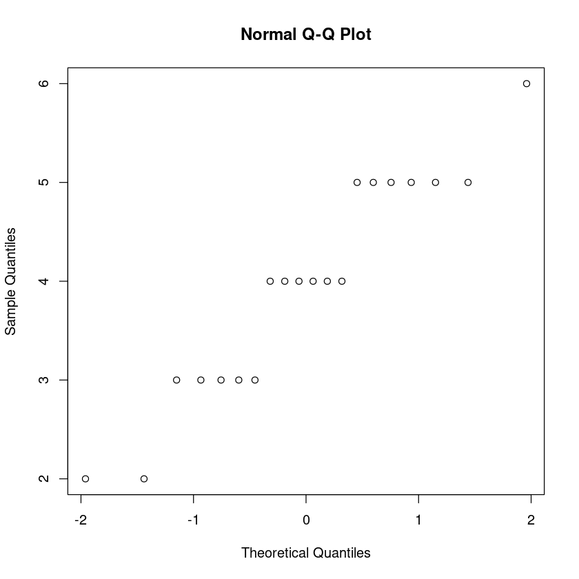

```r
before <- c(120,122,118,130,125,128,115,121,123,119,
            132,127,124,129,117,126,131,118,122,125)

after  <- c(115,120,112,128,122,125,110,117,119,114,
            127,124,120,126,112,122,128,113,118,121)

difference = before - after

qqnorm(difference)
#the differences are from a normal distribution approximately

t.test(before, after, alternative ="greater", paired = TRUE)
```

[output not shown]

### Inference about two proportions

Example: A pharmaceutical company wants to evaluate the effectiveness of a new headache medication. They conduct a study with two groups: 500 participants receive the new drug (experimental group), and 400 participants receive a placebo (control group). In the experimental group, 350 participants report that their headache subsided within 15 minutes, while in the placebo group, 235 participants report the same outcome.

Conduct a hypothesis testing to see if the success rate is higher in the experimental group compared to the placebo group? Perform a hypothesis test at the 0.01 significance level to determine this.

$H_0$: the success rate of the experimental group is the same as that of the placebo group.

$H_1$: the success rate of the experimental group is higher than that of the placebo group.

The success rate of the experimental group is a proportion.